# Function (Intro)

Alex Filazzola

May 28, 2020

### Introduction to R functions

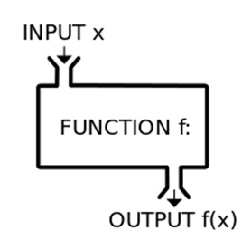

```r
library(tidyverse)
library(ggthemes)
```

### Introduction

Writing functions is a fundamental component of programming and therefore scares many people. However! Functions can be easier than you’d think. For example, think of what *your* perfect bar plot looks like. How much time do you spend making your bar plots look like that? Wouldn’t it be great if the very first time you plotted a barplot it looked exactly the way you wanted it to? With functions you can do that, and all the knowledge you’d need is how to make the barplot look the way you want. This works shop gives a quick overview of how to use functions to make your life easier. Demonstrations will be done in R, but are applicable to most languages.

One of the more powerful aspects of programming languages relative GUI statistical softwares is the ability to create functions. Functions are extremely powerful because they allow for the automation of repetitive tasks and reduce bloated code from the more traditional “copy-paste” format. This becomes extremely powerful when combined with the apply family or loops. However, even for simple tasks, functions can make your life easier.

Why use functions?

- save complicated operations or mathematical calculations
- reduce repetitive tasks
- standardize formats (e.g. plots, maps, etc)
- combine with apply family for automation of tasks

### Function Syntax

The format of function is fairly simple:

`function.name <- function(arguments){` `arguments + operation` `}`

Here arguments can be any lists of text or characters that will later be used within the formula. Within the function, the operate will have two general components. Firstly, the portion of the function that will remain unchanged each time it is used. The second are the arguments that will be changed each time.

```r
## Write the first function
plus1 <- function(x){
x+1 ## the arugment and operation
}
plus1(x=5)
```

```
## [1] 6
```

For these functions there are two items that will remain unchanged. The first is the calculation. In the above example, the addition operation will not change and remains the same. These types of functions are useful when you have a particular index that you are trying to calculate, but the inputs will keep changing.

For instance say you want to convert degrees to radians. The function you would write would be this.

```r
deg2rad <- function(deg) {
  (deg * pi) / (180)
}

deg2rad(90)
```

```
## [1] 1.570796
```

```r
## For simpler functions you can write them as one line
deg2rad <- function(deg) {(deg * pi) / (180)}
```

Log response ratio is a calculation when comparing two groups based on a treatment vs control format.

```r
LRR <- function(treatment,control){
  log(treatment/control)
}
LRR(treatment=30, control=20)
```

```
## [1] 0.4054651
```

Here we see that the log response ratio of our two individuals. Specifying the treatments is not entirely necessary. Depending on how you set up your arguments, R will assume your inputs will be in the order that they are presented. The function can also handle any type of data format such as number, vector, shapefile, dataframe, etc, just as long as what is specified within the function can handle it.

```r
treat1 = c(30,40,50,35,45,55)
control1= c(20,25,30,23,25,20)
LRR(treat1, control1)
```

```
## [1] 0.4054651 0.4700036 0.5108256 0.4198538 0.5877867 1.0116009
```

You can also utilize functions alreay present within R.

```r
## Create function to calculate average
average <- function(x){
  sum(x)/length(x)
}

## assign LRR to object
results <- LRR(treat1, control1)
## calculate the average of results from LRR
average(results)
```

```
## [1] 0.5675893
```

There is no standard error function present in base R, so this simple formula below is probably one that I use the most.

```r
se <- function(x){ sd(x)/sqrt(length(x)) } ## sd/sqrt(n)
```